# Univariate Plots Section

# Bivariate Analysis

### Talk about some of the relationships you observed in this part of the investigation. How did the feature(s) of interest vary with other features in the dataset?

```
一开始我认为，残糖含量、有机酸含量、酒精含量是影响品质的主要因素，除此之外还添加了矿物盐含量、溶解气体含量。希望能够把影响品质的因素按照类别合成大块来研究，这五方面会决定品质。但是具体分析的时候发现：
1.最影响品质的两个因素是酒精含量、挥发性酸含量。
2.合成的大块误导了我的研究，尽管品质与有机酸含量的相关性不明显。但与柠檬酸的相关性较强。
3.溶解气体、矿物盐含量、pH、密度这些变量都与品质相关性不明显。
因此，酒精含量、柠檬酸含量、挥发性酸含量，是影响品质的最关键三个因素。
```

### Did you observe any interesting relationships between the other features (not the main feature(s) of interest)?

[output not shown]

### What was the strongest relationship you found?

```
葡萄酒本质还是酒，最强相关的还是酒精含量，在各种化学成分里是最关键的影响因素。其次就是酸，酸可以平衡口感，抗氧化。但并不是每一种酸都会强相关，比如柠檬酸与品质相关性高，而同为有机酸的固定酸度（酒石酸）与品质相关性就会低一些。还有挥发性酸，也是影响品质的主要因素。其他因素，与品质的相关性较低。
```

# Multivariate Plots Section

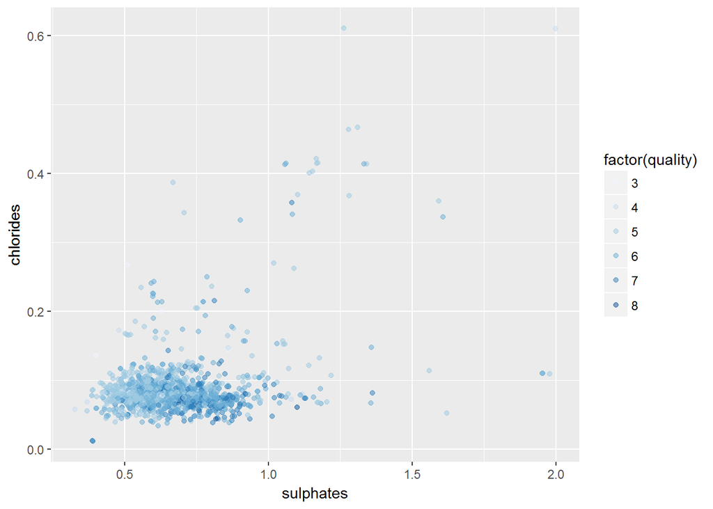

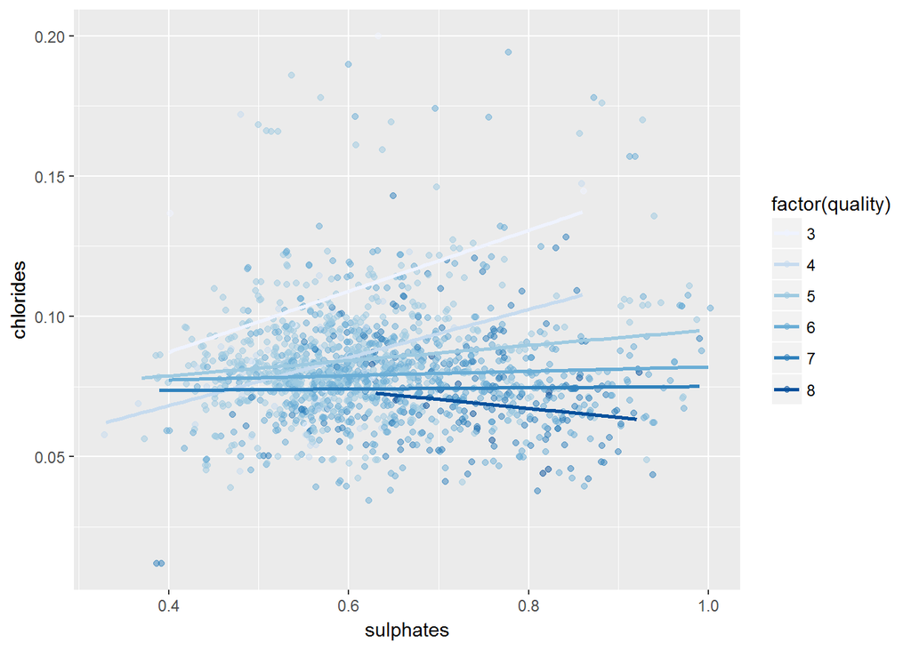

```
## [1] 0.2513971
```

```
只观察硫酸盐小于1，氯化物小于0.2部分。似乎硫酸盐含量也对品质由较强的影响，相关系数0.251，这在之前的合并中被忽略了。除此之外，不同品质下，硫酸盐含量与氯化物含量的趋势线坡度明显不同，猜测可能其比值可能会影响品质。
```

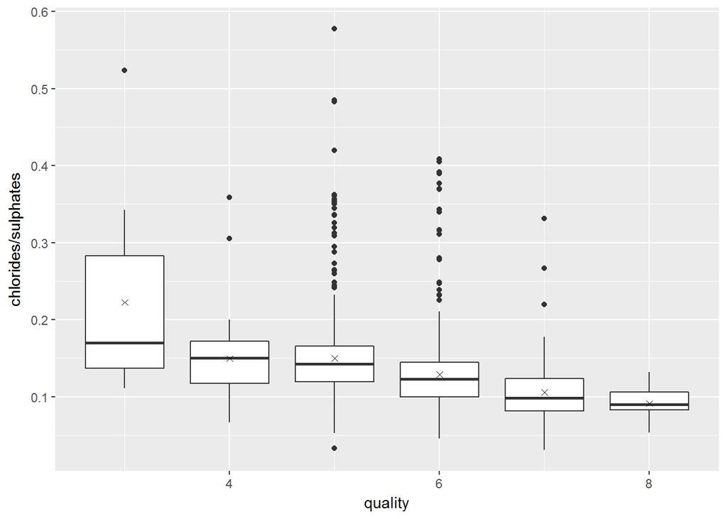

```
## [1] -0.3086931
```

```
## [1] 0.3642651
```

```
从图中可以看出，该比值与品质由明显相关性。氯化物/硫酸盐、品质的相关系数为-0.309，有明显相关性。尝试使用硫酸亚/氯化物、品质，得出相关系数0.364。这个结果要比之前的观察更加好。决定创建该比值变量，以便后期建模使用。
```

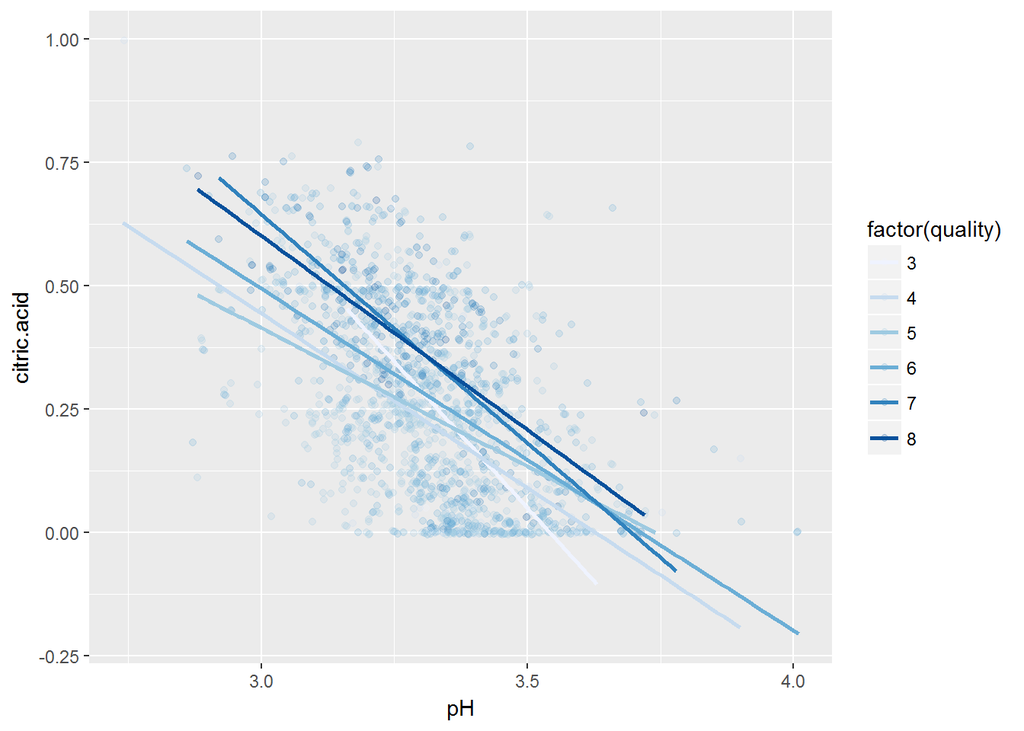

```
柠檬酸与pH之间成反比关系，但是品质为3的趋势线坡度明显不同于其他。猜测柠檬酸与pH的比值可能与品质有关。当这种比例关系小于某个值时，可能会造成葡萄酒品质突降。
```

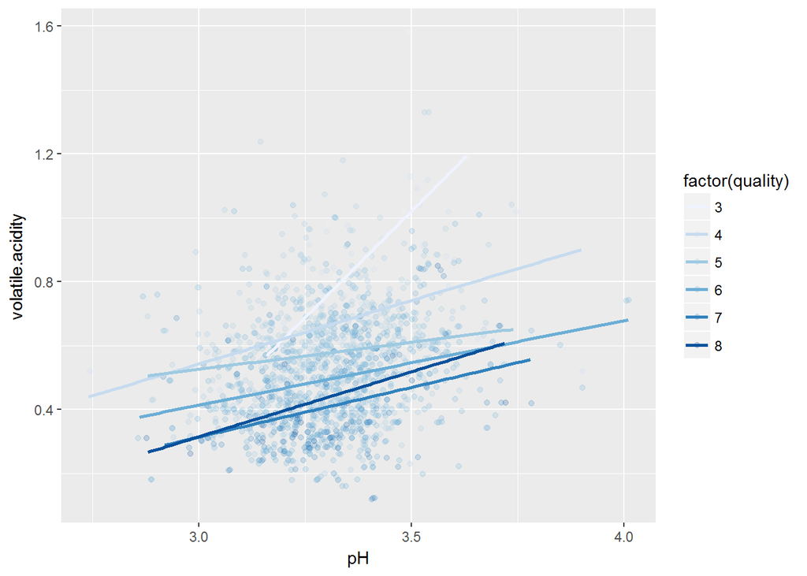

```
挥发性酸与PH值成正比，与柠檬酸相似的是，在品质为3的等级下，趋势线的坡度明显不同于其他品质。同样，猜测挥发性酸与PH的比值与品质有关。当其大于某个值时，可能会造成品质突降。
```

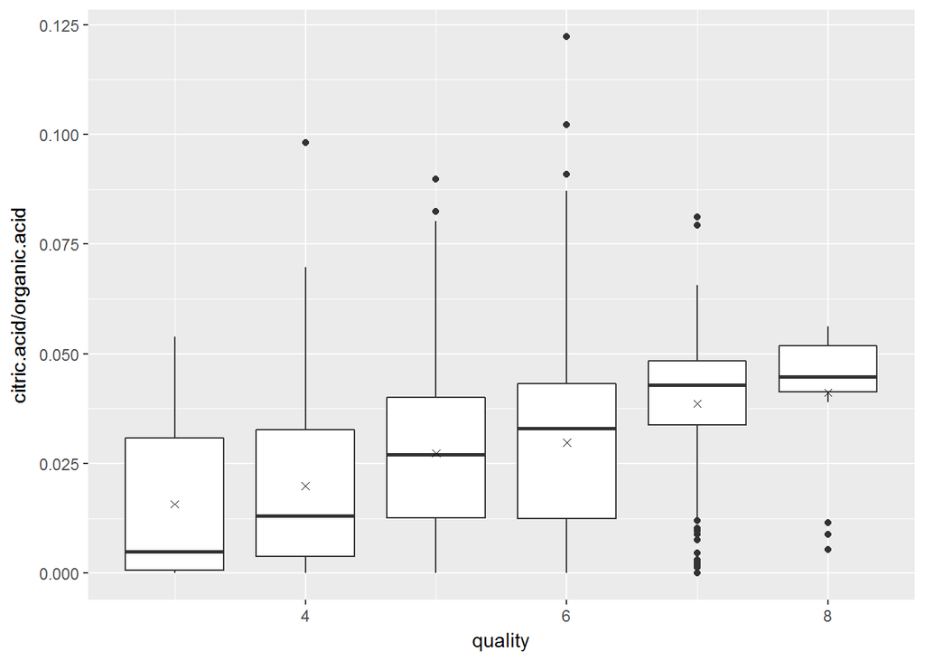

```
## [1] 0.2098039
```

```
柠檬酸占有机酸的比例与品质成正相关，相关系数0.21。相比之下，柠檬酸本身与品质的相关度更高。
```

```
##
## Calls:
## m1: lm(formula = quality ~ alcohol, data = df)
## m2: lm(formula = quality ~ alcohol + volatile.acidity, data = df)
## m3: lm(formula = quality ~ alcohol + volatile.acidity + s_div_c,
##     data = df)
##
## ==============================================================
##                          m1            m2            m3
## --------------------------------------------------------------
##   (Intercept)           1.875***      3.095***      3.074***
##                        (0.175)       (0.184)       (0.182)
##   alcohol               0.361***      0.314***      0.277***
##                        (0.017)       (0.016)       (0.017)
##   volatile.acidity                   -1.384***     -1.233***
##                                      (0.095)       (0.097)
##   s_div_c                                           0.039***
##                                                    (0.006)
## --------------------------------------------------------------
##   R-squared             0.227         0.317         0.334
##   adj. R-squared        0.226         0.316         0.333
##   sigma                 0.710         0.668         0.659
##   F                   468.267       370.379       267.097
##   p                     0.000         0.000         0.000
##   Log-likelihood    -1721.057     -1621.814     -1601.199
##   Deviance            805.870       711.796       693.678
##   AIC                3448.114      3251.628      3212.399
##   BIC                3464.245      3273.136      3239.284
##   N                  1599          1599          1599
## ==============================================================
```

# Multivariate Analysis

### Talk about some of the relationships you observed in this part of the investigation. Were there features that strengthened each other in terms of looking at your feature(s) of interest?

```
在多变量观察的时候，通过引入不同品质下的趋势线，看到其他两个变量比值与品质的关系。尤其是找到了硫酸盐/氯化物与品质之间的明显相关。同样观察了感兴趣的柠檬酸在有机酸占比与品质的关系，结果并不理想，甚至低于柠檬酸本身与品质的相关性。于是决定使用新变量硫酸盐/氯化物来代替柠檬酸建模。
```

### Were there any interesting or surprising interactions between features?

```
各个变量都属于数值型变量，只有品质可转为factor观察。想观察双变量之间的关系是否对品质有影响，于是引入不同品质下，双变量的趋势线，该趋势线的坡度可以说明双变量之间的关系，结合品质，观察到的结果有：
1.硫酸盐/氯化物的比值与品质有明显相关性，相关系数为0.364。
2.柠檬酸与pH值成反比，柠檬酸/pH如果过于小，会对品质造成严重影响,品质下降很快。
3.挥发性酸与pH值成正比，挥发性酸/pH如果过于大，会对品质造成严重影响，品质下降很快。
4.柠檬酸本身与品质的相关性，高于柠檬酸/有机酸与品质的相关性。
```

### OPTIONAL: Did you create any models with your dataset? Discuss the strengths and limitations of your model.

```
是的，建立了一个线性模型。分别使用酒精含量、挥发酸度、硫酸盐/氯化物。但是效果并不是很理想。整个模型是线性模型，而品质应该属于分类变量。在分析的过程中，是使用箱线图完成分析，结合相关系数，找出主要因素，建立的线性模型。如果能使用某些分类模型去预测，效果可能会更好。
```

# Final Plots and Summary

### Plot One

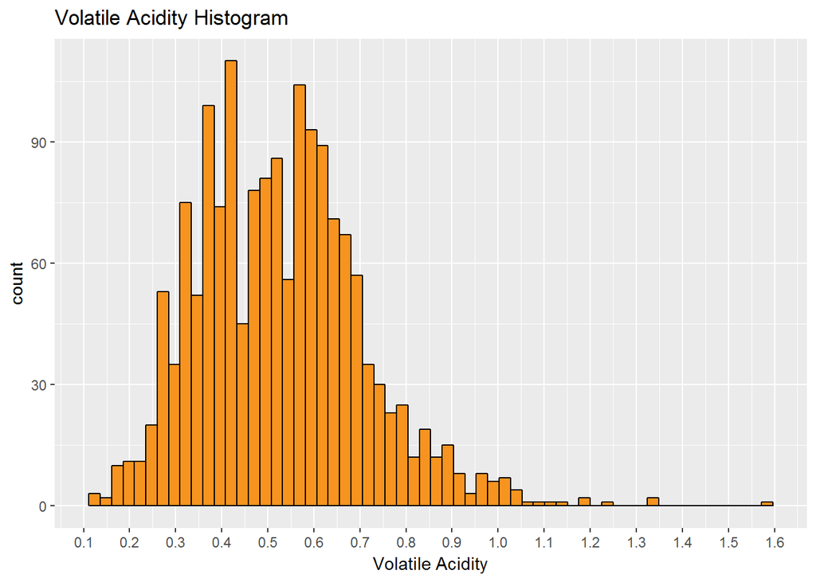

### Description One

```
挥发性酸的分布直方图，存在个别极值，呈现双峰分布。主要围绕在0.35和0.6周围
```

### Plot Two

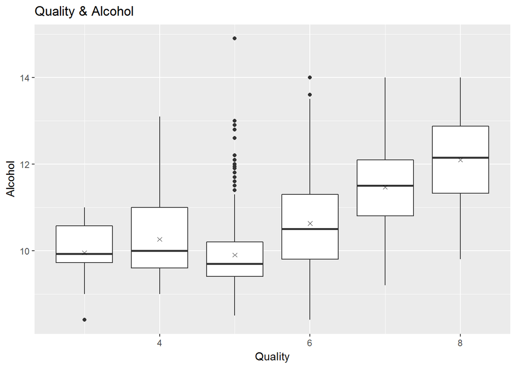

### Description Two

[output not shown]

### Plot Three

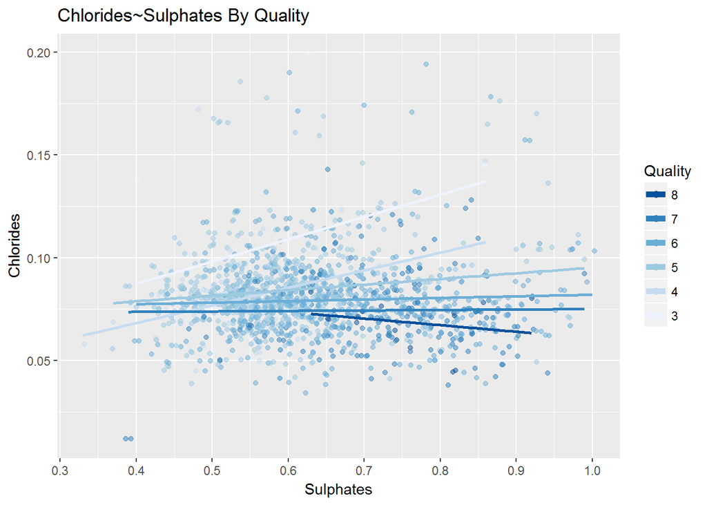

### Description Three

```
观察到不同品质下，硫酸盐与氯化物的趋势线坡度均不相同。猜测硫酸盐与氯化物之间的关系会对品质造成明显影响。通过计算相关系数得出，硫酸盐/氯化物与品质有明显相关性，相关系数为0.364
```

# Reflection

```
数据集含有1599条记录，11个输入变量，一个结果变量，所有变量都为数值型。在最初开始，我错误的将部分变量合并为大的分类，导致没能观察到正确的相关性。比如，我猜测有机酸、酒精、残糖含量会与葡萄酒品质相关性更强，而根据之后的探索得出的结果是，酒精、挥发性酸、硫酸盐/氯化物与品质有明显相关性。
之后根据探索的结果，初步建立了线性模型，预测效果不是很好。我猜测，是因为尽管找到的变量与品质相关性更强，也有一定的线性关系。但是，葡萄酒品质的预测按照1到10的得分，更接近于分类问题，线性模型更适合预测连续性结果，对于分类问题采用分类模型可能会有一个更好的结果。
除此之外，对多变量的探索分析还不够深入，尤其是硫酸盐与氯化物的比值对品质有较大影响的发现，让我忽然意识到，各个化学成分之间的相互作用才是影响品质的关键因素，并不是单独的某一个化学成分，或者某一类化学成分，这也符合常识。我需要更深入的研究多变量之间的关系，比如观察在不同品质下，所有变量两两组合的趋势线。这是继续深入研究，优化模型的一个方向。
如果能有更多、更大的数据集，可能还会发现更有趣的现象。也可以在已有数据集下使用分类模型，估计会得到一个更好的预测模型。
```